# Case Study#2

Younju

#### 1) ( Simulation을 이용한 Portfolio 최적화 ) * $P_t$ : t 시점의 주식가격, $t=0,1,2,...$

- t 시점의 주가 수익률(return) : $r_t = (P_t - P_t-1)/P_t-1$
- t 시점 로그수익률 (log-return) : $ln(1+r_t) = lnP_t - lnP_t-1$
- 로그수익률의 분포가
  1. 서로 독립이고
  2. $ln(1+r_t)$ ~ $N(\mu , \sigma^2 )$, $t=1,2,...$를 따른다고 가정하자.
- 단, $\mu$ : 연평균 로그 수익률 = 0.05  
  $\sigma$ : 로그 수익률의 표준편차 (주가 변동성: volatility) = 0.3 이다.

이때,

- $V_0$ : 초기 투자금액 (initial fortune 단위 억원) = 1억원
- $n$ : 투자기간 (만기: maturity) (단위 년) = 5년
- $i$ : 정기예금금리 (risk-free interest rate) = 0.02
- 5 년간 연평균 목표수익률을 4%로 설정하였다.  
  $r^*$ : 목표수익률 ( target return) = 0.04

매년 총자산중 일정비율 a ,$0≦ a ≦$ 1 만큼은 위험자산(risky asset) 주식(stock)에 투자하고 나머지는 연 $100*r_0$%인 정기예금에 투자할 경우 미래 $t$ 시점의 펀드의 자산가치 $V_t$는 아래와 같이 주어진다.

$V_1=V_0(1+r_{p1})$  
$V_2=V_1(1+r_{p2})=V_0(1+r_{p1})(1+r_{p2})$  
$....$  
$V_4 = V_0 \prod_{j=1}^{t} (1+r_{pj}) , t=1,2,...$

단,$t$시점의 Portfolio a의 수익률 $r_{pt} (a)$은

$r_{pt}(a) = (1-a)*i + a*r_t, t=1,2,...$ 로 주어진다.

Portfolio의 투자성과를 판단하는 객관적 기준으로 만기(n)시점의 Portfolio의 자산가치 $V_n(a)$가 연평균 목표 수익률($r^*$)을 초과할 확률(Roy 의 Safety First Criterion):  
$RSFC(a)=P(V_n(a)>V_0(1+r^*)^n )$ 을 설정하고 이 확률값을 Simulation 방법으로 구한다.  
Setup

```r
library(tidyverse)
library(knitr)
library(kableExtra)
```

1. a= 0.5 이고 Simulation 반복 횟수가 $M=1000$경우 목표달성확률을 구하시오.
1. 난수 생성 시 1000*20개의 정규 확률난수(normal random number) 를 생성

```r
total <- 20; sim <- 1000

#given data
mu <- 0.05
sigma <- 0.3
v0 <- 1
maturity <- 5
risk.free.interst <- 0.02
target.return <- 0.04
a <- 0.5

# 비율, 목표수익률, 만기에 따른 함수 생성
portfolio <- function(mu, sigma, a, target.return, total) {
  set.seed(1234)
    #random.matrix
    random.matrix <- matrix(rnorm(sim*total, 0, 1), sim, total)
    #v0~v20 value matrix
    value.matrix <- matrix(1, sim, total+1) #v0~v20
    colnames(value.matrix) <- c(0:total) #assign Colnames
    value.matrix[,1] <- c(1)         #set V0 to 1
    #Calculate rates
    rt <- exp(mu + sigma * random.matrix) - 1  #Stock return at t
    rpt_a <- (1 - a)*risk.free.interst + a * rt   #t시점의 Portfolio a의 수익률
    for (i in 1:total) {
      value.matrix[,i+1] <- value.matrix[,i]*(1+rpt_a[,i])
     }
return(value.matrix)
}
```

2. 1000번의 Simulation 중 목표달성조건을 만족하는 경우의 횟수를 구한 후 1000으로 나누어 해당 확률값을 구함

```r
#만기시점의 portfolio의 자산가치가 연평균 목표 수익율을 초과할 확률 (Roy의 Safety First Criterion)
rsfc <- function(mu, sigma, a, target.return, total) {
  # maturity matrix (1~20년)
  maturity.matrix <- matrix(1:total, 1, total)
  # n=1~20/ 목표 수익율
  target.matrix <- matrix(1*(1+target.return)^maturity.matrix, sim, total, byrow = TRUE)
  value.matrix <- portfolio(mu, sigma, a, target.return, total)
  rsfc <- colMeans(matrix(as.numeric(value.matrix[,-1]>target.matrix), sim, total))
  return(rsfc)
}
```

목표 달성 확률

```r
rsfc(mu, sigma, a, target.return, total)
```

```
##  [1] 0.470 0.497 0.514 0.518 0.534 0.542 0.544 0.567 0.568 0.568 0.571
## [12] 0.561 0.571 0.570 0.584 0.572 0.569 0.566 0.565 0.568
```

2. 처음 5번의 Simulation에 대하여 $V_t(a), t=1,...10$ 의 시계열도표를 겹처서 그려보시오.

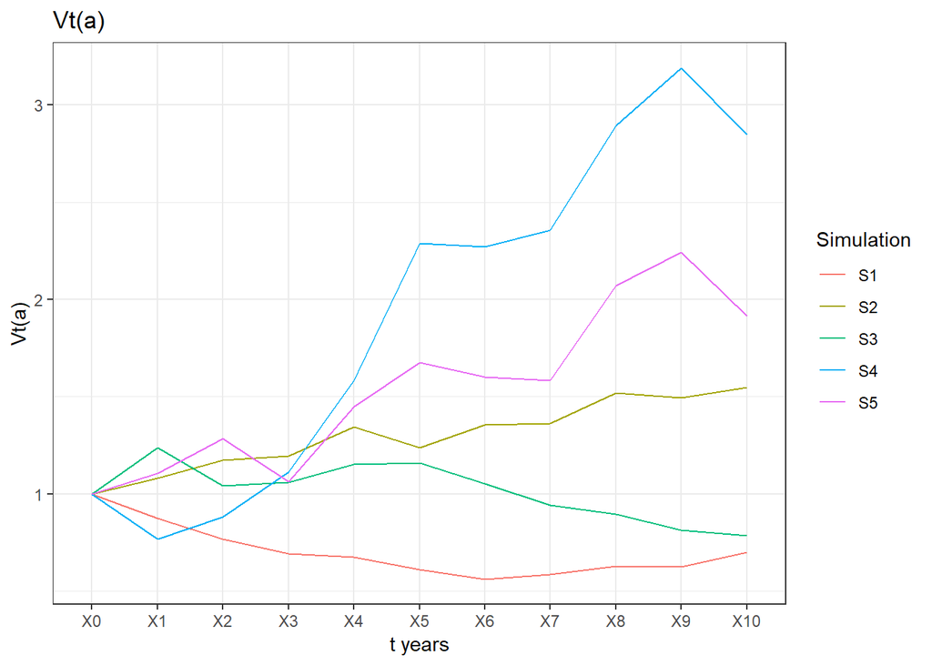

```r
v.1_5 <- portfolio(mu, sigma, a, target.return, total)[1:5, 1:11] #choose v1 to v10
df <- data.frame(Simulation=c('S1','S2','S3','S4','S5'),v.1_5)
newdf <- gather(df, type, value, -Simulation)
ggplot(newdf,aes(x = type, y = value, group = Simulation, color = Simulation) ) +
  geom_line() +
  labs(x='t years',y='Vt(a)', title = 'Vt(a)') +
  scale_x_discrete(limit=c("X0","X1","X2","X3","X4","X5","X6","X7","X8","X9","X10")) +
  theme_bw()
```

3. Portfolio $a=0, 0.1, ..., 1$ $0 \leq a \leq 1$ 일 때 목표달성확률을 구하고 이 값들의 그래프를 그리시오.

```r
a.table <- matrix(c(seq(0, 1, 0.1), rep(0,11)), 11, 2)
for (i in 0:10){
a.table[i+1, 2] <- rsfc(mu, sigma, i/10, target.return, maturity)[maturity]
}
colnames(a.table) <- c("a", "prob.")
a.table
```

```
##         a prob.
##  [1,] 0.0 0.000
##  [2,] 0.1 0.188
##  [3,] 0.2 0.393
##  [4,] 0.3 0.479
##  [5,] 0.4 0.516
##  [6,] 0.5 0.534
##  [7,] 0.6 0.540
##  [8,] 0.7 0.543
##  [9,] 0.8 0.545
## [10,] 0.9 0.540
## [11,] 1.0 0.539
```

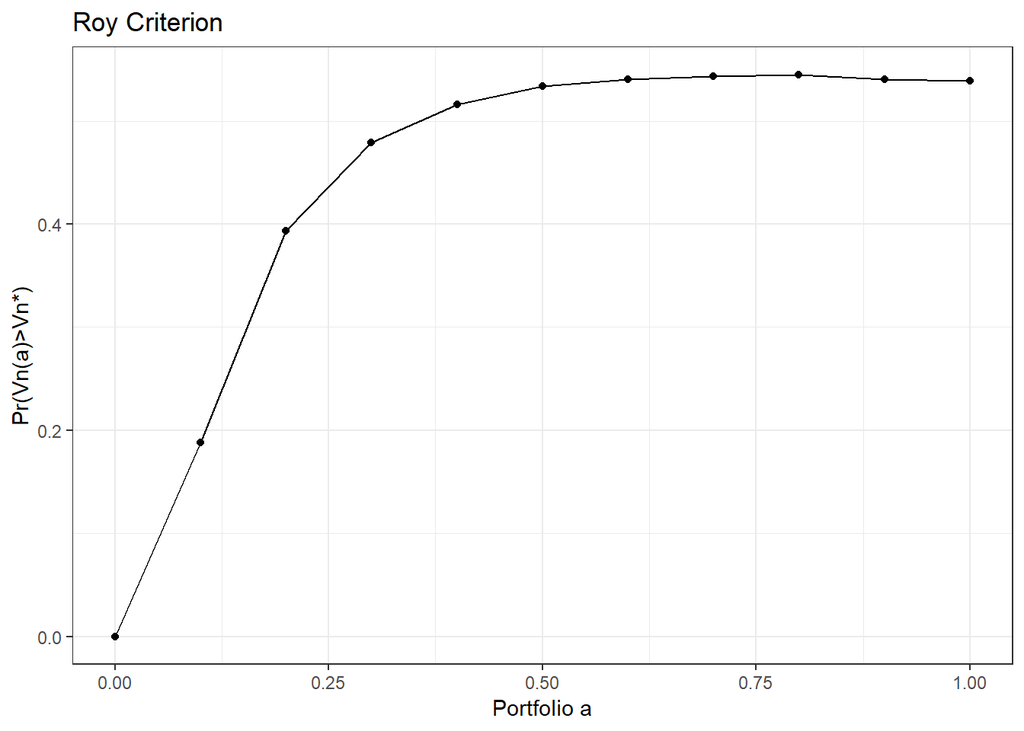

```r
ggplot(data.frame(a.table), aes(a, prob.)) +
  geom_point() + geom_line() +
  labs(title = 'Roy Criterion', x="Portfolio a", y='Pr(Vn(a)>Vn*)')  +
  theme_bw()
```

4. 목표달성확률을 최대로 하는 a값 a* 및 목표달성확률을 구하시오.

```r
sensitivity <- function(mu, sigma, target.return, maturity) {
  prob <- NA
  for (i in 0:10){
    prob[i+1] <- rsfc(mu, sigma, i/10, target.return, maturity)[maturity]
  }
  a.star_prob <- max(prob)
  a.star <- sprintf('%.1f',0.1*(which.max(prob)-1))
  opt.a <- data.frame("a.star"=a.star, "prob"=a.star_prob)
    return(opt.a)
}
kable(sensitivity(mu, sigma, target.return, maturity)) %>%
  kable_styling(full_width = F,
                position = "left")
```

| a.star | prob |
| --- | --- |
| 0.8 | 0.545 |

5. (Sensitivity Analysis) 위 방법을 이용하여 목표수익률 $r^*$ 와 만기 $n$가 아래와 같이 주어질 경우,  
   최적 Portfolio a*및 예상되는 목표 달성 활률을 구하는 표를 오나성하시오.

```r
e.sensitivity <- rbind(sensitivity(mu, sigma, target.return=0.03, maturity=5),
                       sensitivity(mu, sigma, target.return=0.03, maturity=10),
                       sensitivity(mu, sigma, target.return=0.04, maturity=5),
                       sensitivity(mu, sigma, target.return=0.04, maturity=10),
                       sensitivity(mu, sigma, target.return=0.06, maturity=5),
                       sensitivity(mu, sigma, target.return=0.06, maturity=10))

kable(cbind("r*"=c(0.03, 0.03, 0.04, 0.04, 0.06, 0.06), "만기 n"=rep(c(5,10),3),e.sensitivity))%>%  kable_styling(full_width = FALSE, position="left")
```

| r* | 만기 n | a.star | prob |
| --- | --- | --- | --- |
| 0.03 | 5 | 0.5 | 0.592 |
| 0.03 | 10 | 0.4 | 0.638 |
| 0.04 | 5 | 0.8 | 0.545 |
| 0.04 | 10 | 0.7 | 0.584 |
| 0.06 | 5 | 1.0 | 0.482 |
| 0.06 | 10 | 0.9 | 0.489 |

#### 2) (Stock Price Model)

Problem : (KOSPI 수익률분포 찾기)  
#1 에서 최적 Portfolio를 구하기 위해 필요한 주식의 로그수익률 $ln(1+r_t)$ 분포를 2004.1-2018.1. 기간의 매 월말 KOSPI 시계열자료를 이용하여 구한다.  
setup

```r
#setting
library(lubridate)
setwd("D:\\0_grad\\data")
kospi <- read.csv("kospi.csv", skip=3)
```

1. 2004.1-2018.1 기간 월별 KOSPI 주가지수자료에 대해 $P_t$ 및 $lnPt$ 의 시계열도표(Time Series Plot)를 각 각 그리시오.

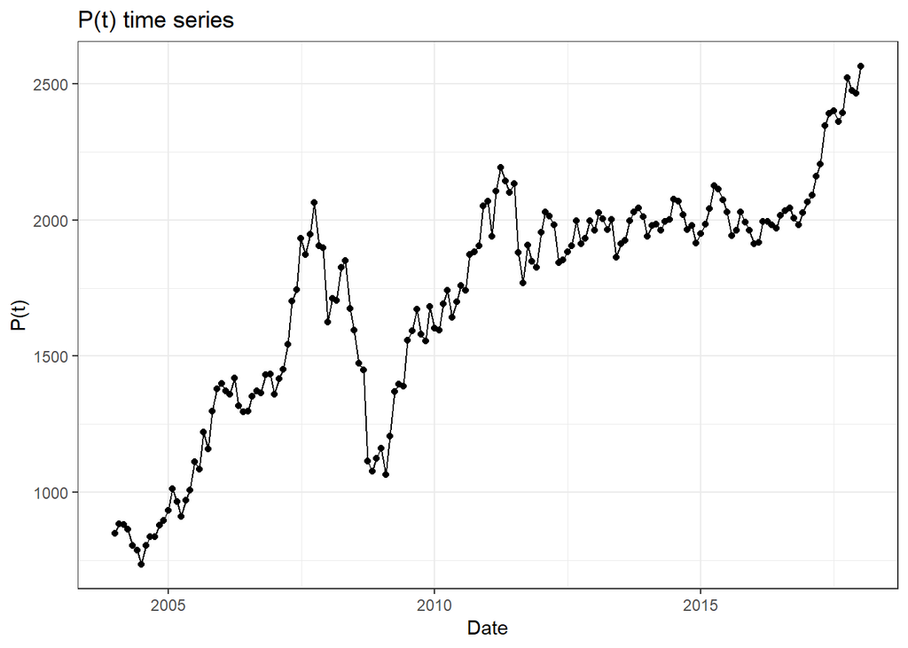

```r
#data setting
colnames(kospi) <- c("Date", "P")
kospi$P <- as.numeric(gsub( ",", "", kospi$P))
kospi$Date <- as.POSIXlt(paste(kospi$Date, 1, sep="/"), format="%Y/%m/%d")
kospi$Date <-as.Date(kospi$Date)
kospi <- kospi %>% mutate(lnPt=log(as.numeric(P)))

#Time Series Plot
#Pt
ggplot(kospi, aes(Date, P)) +
  geom_point() + geom_line() +
  theme_bw() + labs(title="P(t) time series", x="Date", y="P(t)")
```

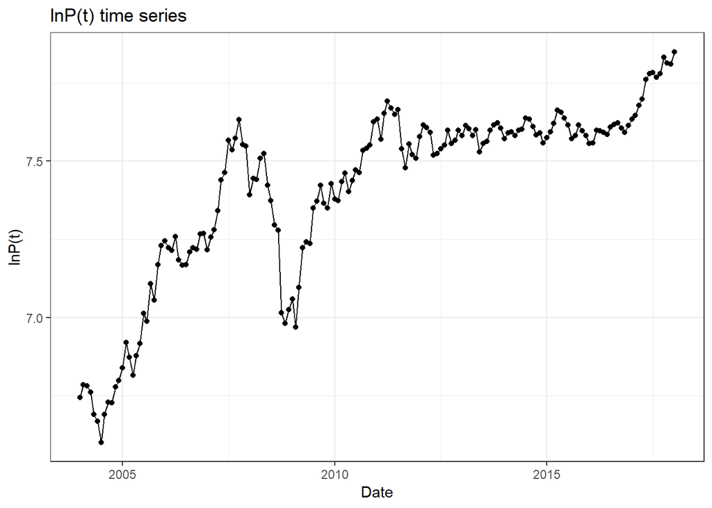

```r
#lnPt
ggplot(kospi, aes(Date, lnPt)) +
  geom_point() + geom_line() +
  theme_bw() + labs(title="lnP(t) time series", x="Date", y="lnP(t)")
```

2. 월별 로그주가지수 $lnP_t$ 자료의 차분 (Difference) $\triangledown lnP_t = lnP_t - lnP_{t-1}$를 계산하고  
   $r_t=(P_t - P_{t-1})/P_{t-1} = P_t/P_{t-1} - 1, t=1,...,m$  
   $ln(1+r_t)=\triangledown lnP_t$  
   을 이용하여 로그수익률 $ln(1+r_t)$ 시계열도표 및 히스토그램을 그려보시오.

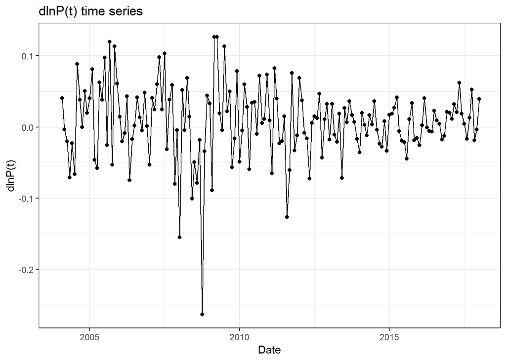

```r
kospi$dlnPt[1] <- NA
for (i in 2:nrow(kospi)){
  kospi$dlnPt[i] <- kospi$lnPt[i] -kospi$lnPt[i-1]
}
#time series
ggplot(kospi, aes(Date, dlnPt)) + geom_point() + geom_line() +
  theme_bw() +labs(title="dlnP(t) time series", x="Date", y="dlnP(t)")
```

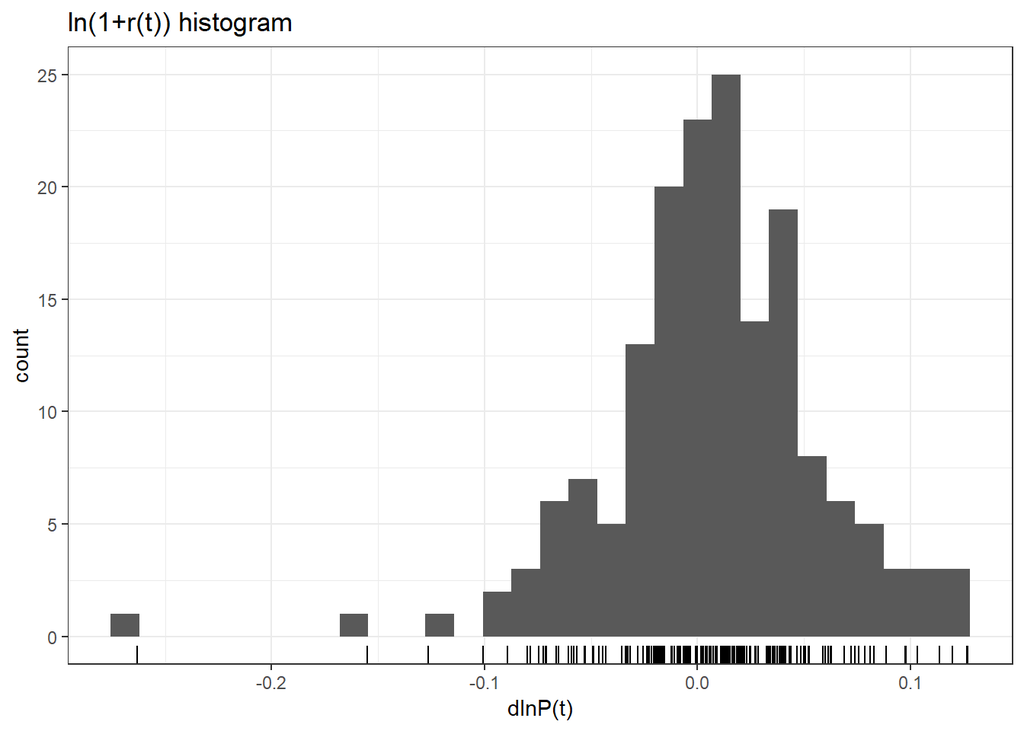

```r
#Histogram
ggplot(kospi) + geom_histogram(aes(dlnPt), stat="bin") + geom_rug(aes(dlnPt)) +
  theme_bw() +labs(title="ln(1+r(t)) histogram", x="dlnP(t)")
```

c) (정규성 검정) 로그수익률 $ln(1+r_t)$ 분호가 정규분포를 따르는지 정규 Q-Q plot을 그려보고 정규성 가정이 성립 하는지 검토하시오.

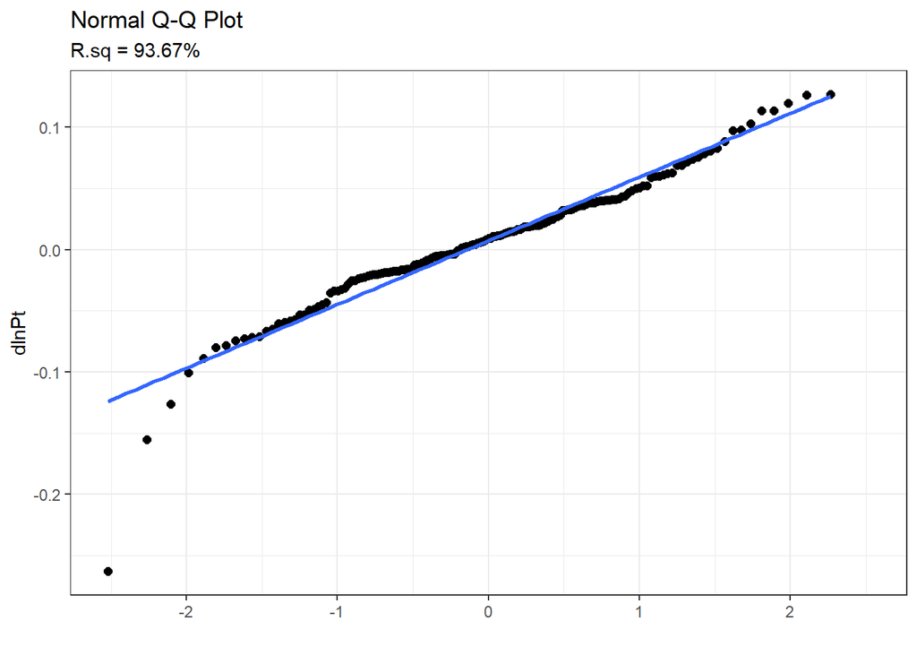

```r
kospi <- kospi %>% mutate(rank=rank(dlnPt), pr=rank/(nrow(kospi)+1)) %>% mutate(norm=qnorm(pr))
ggplot(kospi, aes(norm, dlnPt)) + geom_point(size=2) +
  geom_smooth(method="lm", se=F) +
  labs(title = "Normal Q-Q Plot",
       subtitle = paste("R.sq = ", round(summary(lm(dlnPt ~ norm, kospi))$r.squared,4)*100, "%", sep = ""),
       x="", y="dlnPt") + theme_bw()
```

직선에 가까우므로 정규성 가정이 성립한다.

4. 로그 수익률 $ln(1+r_t)$의 분포가 서로 독립이고 아래와 같은 정규분포를 따른다고 가정할때  
   $ln(1+r_t)=lnP_t - lnP_{t-1}$ ~ $N(\mu dt , \sigma^2 dt),$ $t=1,2,...$  
   단, $dt=1/12$ (월별자료)  
   미지 모수 $(\mu, \sigma)$ 추정하시오.

```r
mu.kospi <- 12*mean(kospi$dlnPt, na.rm=TRUE)
sd.kospi <- sqrt(12)*sd(kospi$dlnPt, na.rm=TRUE)
c(mu.kospi, sd.kospi)
```

```
## [1] 0.07905805 0.17885606
```

5. 위에서 구한 추정값 $(\hat{\mu}, \hat{\sigma})$을 이용하고 #1을 활용하여 만기 n=10, 목표수익률 r*=0.04인경우 ㅋ정기예금과 KOSPI에 매년 각각 (1-a, a)만큼 투자하는 포트폴리오중 최적 포트폴리오 a* 및 해당 목표달성확률을 각각 구하시오.

```r
kable(sensitivity(mu=mu.kospi, sigma=sd.kospi, target.return=0.04, maturity=10)) %>%
  kable_styling(full_width = F,
                position = "left")
```

| a.star | prob |
| --- | --- |
| 1.0 | 0.752 |

6. (Sensitivity Analsis) 위 방법을 이용하여 목표수익률 $r^*$와 만기 n이 아래와 같이 주어질 경우 최적 Portfolio $a^*$및 예상되는 목표 달성 확률을 구하는 표를 완성하시오.

```r
f.sensitivity <- rbind(sensitivity(mu=mu.kospi, sigma=sd.kospi, target.return=0.04, maturity=5),
                       sensitivity(mu=mu.kospi, sigma=sd.kospi, target.return=0.04, maturity=10),
                       sensitivity(mu=mu.kospi, sigma=sd.kospi, target.return=0.04, maturity=20),
                       sensitivity(mu=mu.kospi, sigma=sd.kospi, target.return=0.05, maturity=5),
                       sensitivity(mu=mu.kospi, sigma=sd.kospi, target.return=0.05, maturity=10),
                       sensitivity(mu=mu.kospi, sigma=sd.kospi, target.return=0.05, maturity=20))

kable(cbind("r*"=c(0.04, 0.04, 0.04, 0.05, 0.05, 0.05), "만기 n"=rep(c(5,10,20),2),f.sensitivity))%>%  kable_styling(full_width = FALSE, position="left")
```

| r* | 만기 n | a.star | prob |
| --- | --- | --- | --- |
| 0.04 | 5 | 1.0 | 0.680 |
| 0.04 | 10 | 1.0 | 0.752 |
| 0.04 | 20 | 1.0 | 0.855 |
| 0.05 | 5 | 1.0 | 0.638 |
| 0.05 | 10 | 1.0 | 0.701 |
| 0.05 | 20 | 1.0 | 0.792 |